# -------------INDEX OF THE SOLUTION---------------

# 9. SELECTING THE TOP CATEGORICAL FEATURES

## We'll use SelectKBest library to narrow down choices of features. This will make use of CHI2 test.

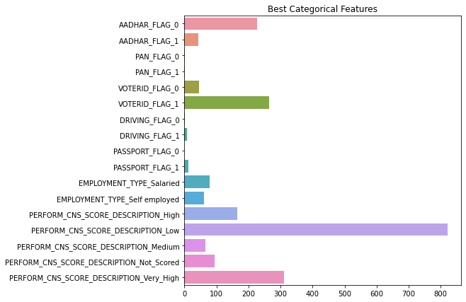

```python
c = SelectKBest(score_func=chi2)
numcols=c.fit(X_train_categorical_encoded,y_train)
plt.figure(figsize=(7,7))
sns.barplot(x=numcols.scores_,y=encodedCatColumnNames)
plt.title('Best Categorical Features')
plt.show()
```

```python
## Creating dictionaries to store the feature names and its importance value
topCatFeatures={}

## https://machinelearningmastery.com/feature-selection-with-categorical-data/
for i in range(len(c.scores_)):
#     print('Feature %s: %f' % (numerical[i], n.scores_[i]))
    topCatFeatures[encodedCatColumnNames[i]]=c.scores_[i]

# SORT THE DICTIONARY AS PER THE IMPORTANT SCORES
topCatFeatures = sorted(topCatFeatures.items(), key=lambda x: x[1],reverse=True)
print("-----------------------TOP FEATURES SORTED AS PER THE HIGH IMPORTANCE----------------")
topCatFeatures
```

```
-----------------------TOP FEATURES SORTED AS PER THE HIGH IMPORTANCE----------------
```

```
[('PERFORM_CNS_SCORE_DESCRIPTION_Low', 822.5233338845148),
 ('PERFORM_CNS_SCORE_DESCRIPTION_Very_High', 310.7573602489819),
 ('VOTERID_FLAG_1', 264.2875342865508),
 ('AADHAR_FLAG_0', 225.81119820550776),
 ('PERFORM_CNS_SCORE_DESCRIPTION_High', 165.4521970472589),
 ('PERFORM_CNS_SCORE_DESCRIPTION_Not_Scored', 93.41588624893859),
 ('EMPLOYMENT_TYPE_Salaried', 78.49242457000814),
 ('PERFORM_CNS_SCORE_DESCRIPTION_Medium', 65.81329302091638),
 ('EMPLOYMENT_TYPE_Self employed', 60.049034943086276),
 ('VOTERID_FLAG_0', 44.83173593070442),
 ('AADHAR_FLAG_1', 42.78611119494228),
 ('PASSPORT_FLAG_1', 11.767562409955424),
 ('DRIVING_FLAG_1', 8.660479890378133),
 ('PAN_FLAG_1', 2.085148232983711),
 ('DRIVING_FLAG_0', 0.2024484040615232),
 ('PAN_FLAG_0', 0.1711506237234707),
 ('PASSPORT_FLAG_0', 0.024276273675145857)]
```

# 10. MERGING THE NUMERICAL AND CATEGORICAL PROCESSSED FEATURES

```python
X_train_merged = pd.concat([X_train_numerical_std,X_train_categorical_encoded], axis=1)
X_test_merged = pd.concat([X_test_numerical_std,X_test_categorical_encoded], axis=1)
```

```python
X_train_numerical_std
```

|  | DISBURSED_AMOUNT | ASSET_COST | LTV | NEW_ACCTS_IN_LAST_SIX_MONTHS | PERFORM_CNS_SCORE | DELINQUENT_ACCTS_IN_LAST_SIX_MONTHS | LOAN_AGE | AGE | AVERAGE_ACCT_AGE | CREDIT_HISTORY_LENGTH | No_of_Accounts | Total_Inactive_accounts | Total_Overdue_Accounts | Total_Current_Balance | Total_Sanctioned_Amount | Total_Disbursed_Amount | Total_Installment |
| --- | --- | --- | --- | --- | --- | --- | --- | --- | --- | --- | --- | --- | --- | --- | --- | --- | --- |
| 0 | 0.125971 | -0.425878 | 0.950321 | 0.642394 | 1.324570 | -0.252379 | 0.614378 | 0.514217 | -0.324522 | -0.428112 | -0.280741 | -0.350434 | -0.286717 | -0.174807 | -0.077531 | -0.077229 | -0.087350 |
| 1 | -0.082823 | -0.387481 | 0.436813 | -0.398491 | 1.194620 | -0.252379 | -1.627663 | -1.118980 | -0.126253 | -0.322965 | -0.093926 | -0.106370 | -0.286717 | -0.109253 | -0.058070 | -0.057772 | -0.074931 |
| 2 | -2.018002 | -0.701566 | -2.334209 | -0.398491 | -0.855044 | -0.252379 | 0.614378 | 0.514217 | -0.588880 | -0.568307 | -0.467555 | -0.350434 | -0.286717 | -0.181252 | -0.082861 | -0.082557 | -0.087350 |
| 3 | -1.457198 | -0.572182 | -1.551721 | 1.683279 | 1.182806 | -0.252379 | 0.614378 | 2.147414 | 0.468554 | 0.728502 | 1.400590 | 1.602079 | -0.286717 | -0.158054 | -0.069265 | -0.069267 | -0.087350 |
| 4 | 1.009165 | 0.279767 | 0.892682 | -0.398491 | 1.156226 | 2.329579 | -1.627663 | -1.629353 | 0.072016 | -0.182769 | -0.093926 | -0.106370 | -0.286717 | -0.159429 | -0.071834 | -0.071533 | -0.065752 |
| ... | ... | ... | ... | ... | ... | ... | ... | ... | ... | ... | ... | ... | ... | ... | ... | ... | ... |
| 163202 | -1.647364 | -1.814013 | 0.886569 | -0.398491 | -0.855044 | -0.252379 | 0.614378 | -0.710680 | -0.588880 | -0.568307 | -0.467555 | -0.350434 | -0.286717 | -0.181252 | -0.082861 | -0.082557 | -0.087350 |
| 163203 | 3.124662 | 3.518889 | -0.434754 | -0.398491 | -0.855044 | -0.252379 | 0.614378 | -1.221054 | -0.588880 | -0.568307 | -0.467555 | -0.350434 | -0.286717 | -0.181252 | -0.082861 | -0.082557 | -0.087350 |
| 163204 | -0.802647 | -0.777993 | -0.014690 | -0.398491 | -0.855044 | -0.252379 | 0.614378 | -0.404456 | -0.588880 | -0.568307 | -0.467555 | -0.350434 | -0.286717 | -0.181252 | -0.082861 | -0.082557 | -0.087350 |
| 163205 | -0.271768 | -0.363385 | -0.002464 | -0.398491 | 1.581516 | -0.252379 | 0.614378 | 0.207993 | -0.192343 | -0.358014 | -0.280741 | -0.106370 | -0.286717 | -0.181252 | -0.082861 | -0.082557 | -0.078357 |
| 163206 | -0.573622 | -0.044638 | -0.881016 | -0.398491 | 1.581516 | -0.252379 | 0.614378 | -0.812755 | -0.060163 | -0.287916 | -0.280741 | -0.106370 | -0.286717 | -0.181252 | -0.082861 | -0.082557 | -0.077008 |

163207 rows × 17 columns

```python
print("Shape of X_train Merged: ",X_train_merged.shape)
print("Shape of X_test Merged: ",X_test_merged.shape)
```

```
Shape of X_train Merged:  (163207, 34)
Shape of X_test Merged:  (69947, 34)
```

```python
print("Shape of y_train : ",y_train.shape)
print("Shape of y_test : ",y_test.shape)
```

```
Shape of y_train :  (163207,)
Shape of y_test :  (69947,)
```

### **OBSERVATION:**

- ## The final no. of features that we will be working are 34. Check the below output for the list of final features.

```python
X_train_merged.columns
```

```
Index(['DISBURSED_AMOUNT', 'ASSET_COST', 'LTV', 'NEW_ACCTS_IN_LAST_SIX_MONTHS',
       'PERFORM_CNS_SCORE', 'DELINQUENT_ACCTS_IN_LAST_SIX_MONTHS', 'LOAN_AGE',
       'AGE', 'AVERAGE_ACCT_AGE', 'CREDIT_HISTORY_LENGTH', 'No_of_Accounts',
       'Total_Inactive_accounts', 'Total_Overdue_Accounts',
       'Total_Current_Balance', 'Total_Sanctioned_Amount',
       'Total_Disbursed_Amount', 'Total_Installment', 'AADHAR_FLAG_0',
       'AADHAR_FLAG_1', 'PAN_FLAG_0', 'PAN_FLAG_1', 'VOTERID_FLAG_0',
       'VOTERID_FLAG_1', 'DRIVING_FLAG_0', 'DRIVING_FLAG_1', 'PASSPORT_FLAG_0',
       'PASSPORT_FLAG_1', 'EMPLOYMENT_TYPE_Salaried',
       'EMPLOYMENT_TYPE_Self employed', 'PERFORM_CNS_SCORE_DESCRIPTION_High',
       'PERFORM_CNS_SCORE_DESCRIPTION_Low',
       'PERFORM_CNS_SCORE_DESCRIPTION_Medium',
       'PERFORM_CNS_SCORE_DESCRIPTION_Not_Scored',
       'PERFORM_CNS_SCORE_DESCRIPTION_Very_High'],
      dtype='object')
```

# 11. CORELATION MATRIX

```python
y_train_corr=pd.DataFrame(y_train)
y_test_corr=pd.DataFrame(y_test)
```

```python
y_train_corr.shape
```

```
(163207, 1)
```

```python
y_train_corr=pd.DataFrame(y_train_corr,columns=['LOAN_DEFAULT'])
y_test_corr=pd.DataFrame(y_test_corr,columns=['LOAN_DEFAULT'])
```

```python
X_train_corr=X_train_merged.copy()
```

```python
X_train_corr['LOAN_DEFAULT']=y_train.values
```

[figure not shown]

```python
corr_mat = X_train_corr.corr()

fig2=plt.figure()
sns.set(rc={'figure.figsize':(30,15)})
k = 34
cols = corr_mat.nlargest(k, 'LOAN_DEFAULT')['LOAN_DEFAULT'].index
cm = np.corrcoef(X_train_corr[cols].values.T)
sns.set(font_scale=1.25)
hm = sns.heatmap(cm, cbar=True, annot=True, square=True, fmt='.2f', annot_kws={'size': 10}, yticklabels=cols.values, xticklabels=cols.values)
plt.title('Correlation Matrix')
plt.show()
```

# 12. MODEL IMPLEMENTATION

## Utility Functions

```python
# This function plots the confusion matrices given y_i, y_i_hat.
def plot_confusion_matrix(test_y, predict_y):
    C = confusion_matrix(test_y, predict_y)
    A =(((C.T)/(C.sum(axis=1))).T)
    B =(C/C.sum(axis=0))
    plt.figure(figsize=(20,4))

    labels = [1,2]
    # representing A in heatmap format
    cmap=sns.light_palette("blue")
    plt.subplot(1, 3, 1)
    sns.heatmap(C, annot=True, cmap=cmap, fmt=".3f", xticklabels=labels, yticklabels=labels)
    plt.xlabel('Predicted Class')
    plt.ylabel('Original Class')
    plt.title("Confusion matrix")

    plt.subplot(1, 3, 2)
    sns.heatmap(B, annot=True, cmap=cmap, fmt=".3f", xticklabels=labels, yticklabels=labels)
    plt.xlabel('Predicted Class')
    plt.ylabel('Original Class')
    plt.title("Precision matrix")

    plt.subplot(1, 3, 3)
    # representing B in heatmap format
    sns.heatmap(A, annot=True, cmap=cmap, fmt=".3f", xticklabels=labels, yticklabels=labels)
    plt.xlabel('Predicted Class')
    plt.ylabel('Original Class')
    plt.title("Recall matrix")

    plt.show()
```

## **-> 12.1. RANDOM MODEL as Benchmark.**

```python
test_len=len(y_test)
```

```
Log loss on Test Data using Random Model 0.8822066722573061
```

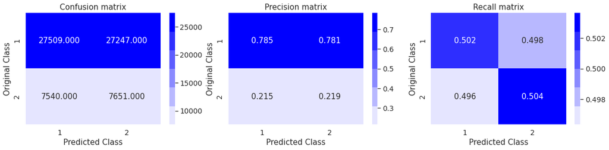

```python
predicted_y = np.zeros((test_len,2))
for i in range(test_len):
    rand_probs = np.random.rand(1,2)
    predicted_y[i] = ((rand_probs/sum(sum(rand_probs)))[0])
print("Log loss on Test Data using Random Model",log_loss(y_test, predicted_y, eps=1e-15))

predicted_y =np.argmax(predicted_y, axis=1)
plot_confusion_matrix(y_test, predicted_y)
```

```python
print("Accuracy On Random Model: ", 50.14)
```

```
Accuracy On Random Model:  50.14
```

## **-> 12.2. Logistic Regression with hyperparameter tuning.**

```python
alpha = [10 ** x for x in range(-5, 2)] # hyperparam for SGD classifier.

log_error_array=[]
for i in alpha:
    clf = SGDClassifier(alpha=i, penalty='l2', loss='log', random_state=42,class_weight="balanced")
    clf.fit(X_train_merged, y_train)
    sig_clf = CalibratedClassifierCV(clf, method="sigmoid")
    sig_clf.fit(X_train_merged, y_train)
    predict_y = sig_clf.predict_proba(X_test_merged)
    log_error_array.append(log_loss(y_test, predict_y, labels=clf.classes_, eps=1e-15))
    print('For values of alpha = ', i, "The log loss is:",log_loss(y_test, predict_y, labels=clf.classes_, eps=1e-15))
```

```
For values of alpha =  1e-05 The log loss is: 0.5213983109193765
For values of alpha =  0.0001 The log loss is: 0.5080405134590263
For values of alpha =  0.001 The log loss is: 0.5063744876271463
For values of alpha =  0.01 The log loss is: 0.5069146614535852
For values of alpha =  0.1 The log loss is: 0.5079726416935862
For values of alpha =  1 The log loss is: 0.5094317419523182
For values of alpha =  10 The log loss is: 0.5114914498434451
```

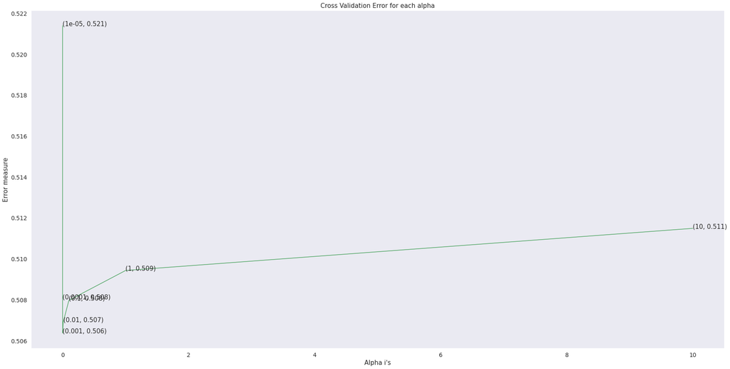

```python
fig, ax = plt.subplots()
ax.plot(alpha, log_error_array,c='g')
for i, txt in enumerate(np.round(log_error_array,3)):
    ax.annotate((alpha[i],np.round(txt,3)), (alpha[i],log_error_array[i]))
plt.grid()
plt.title("Cross Validation Error for each alpha")
plt.xlabel("Alpha i's")
plt.ylabel("Error measure")
plt.rcParams["figure.figsize"] = [10,7]
plt.show()
```

### **OBSERVATION:**

- #### Best value of Alpha is: 0.001

```
For values of best alpha =  0.001 The train log loss is: 0.5064050350783733
For values of best alpha =  0.001 The test log loss is: 0.5067940167557303
Total number of data points : 69947
```

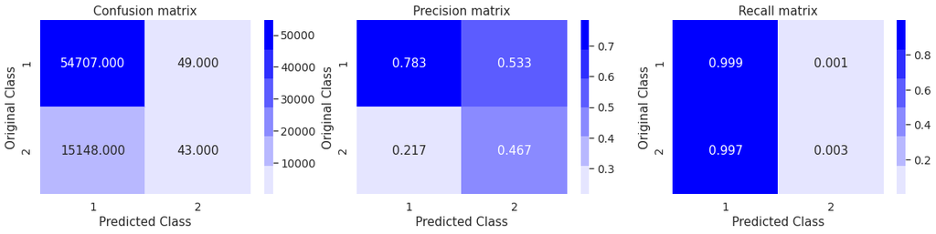

```python
best_alpha = np.argmin(log_error_array)
clf = SGDClassifier(alpha=alpha[best_alpha], penalty='l2', loss='log', random_state=42)
clf.fit(X_train_merged, y_train)
sig_clf = CalibratedClassifierCV(clf, method="sigmoid")
sig_clf.fit(X_train_merged, y_train)

predict_y = sig_clf.predict_proba(X_train_merged)
print('For values of best alpha = ', alpha[best_alpha], "The train log loss is:",log_loss(y_train, predict_y, labels=clf.classes_, eps=1e-15))
predict_y = sig_clf.predict_proba(X_test_merged)
print('For values of best alpha = ', alpha[best_alpha], "The test log loss is:",log_loss(y_test, predict_y, labels=clf.classes_, eps=1e-15))
predicted_y =np.argmax(predict_y,axis=1)
print("Total number of data points :", len(predicted_y))
plot_confusion_matrix(y_test, predicted_y)
```

```python
print("Accuracy On Random Model: ", 78.27)
```

```
Accuracy On Random Model:  78.27
```

## **OBSERVATION:**

- ### The SGD model with Log loss has a very accuracy of 78.27 because of Imbalanced Data, however as we can see from the Confusion Matrix, that the model is performing very poor in classifying the Defaulters

# IMPORTING MODELS

```python
#Importing Machine Learning Model
from sklearn.linear_model import LogisticRegression
from sklearn.neighbors import KNeighborsClassifier
from sklearn.ensemble import RandomForestClassifier

#Bagging Algo
from sklearn.tree import DecisionTreeClassifier
from xgboost import XGBClassifier

#statistical Tools
from sklearn.metrics import roc_auc_score,accuracy_score,precision_score,recall_score,f1_score
from sklearn.metrics import confusion_matrix, roc_curve, auc
```

# Creating Objects of the MODELS

- ## 1. Logistic Regression
- ## 2. KNN
- ## 3. Decision
- ## 4. Random Forest
- ## 5. XGBoost

# NOTE: Data is balanced with the help of the Classifiers inbuilt "class_weight" parameter.

### For optimal performance, it is always recommened to use the inbuilt data balancing parameters of classifiers to balance the data than any other techniques of Upsamling like Sampling with Repeatation or SMOTE: Synthetic Minority Over-sampling Technique. Hence we are using the Classifier parameter.

```python
lr = LogisticRegression(C=5.0,class_weight="balanced")
knn = KNeighborsClassifier(weights='distance', algorithm='auto', n_neighbors=15)
rfc = RandomForestClassifier(n_estimators=300,criterion='gini',class_weight="balanced")
dtc = DecisionTreeClassifier(class_weight="balanced")
```

```python
accuracy = {}
roc_r = {}

def train_model(model):
    # Checking accuracy
    model = model.fit(X_train_merged, y_train)
    pred = model.predict(X_test_merged)
    acc = accuracy_score(y_test, pred)*100
    accuracy[model] = acc
    print('accuracy_score',acc)
    print('precision_score',precision_score(y_test, pred)*100)
    print('recall_score',recall_score(y_test, pred)*100)
    print('f1_score',f1_score(y_test, pred)*100)
    roc_score = roc_auc_score(y_test, pred)*100
    roc_r[model] = roc_score
    print('roc_auc_score',roc_score)
    # confusion matrix
    print('confusion_matrix')
    plot_confusion_matrix(y_test,pred)
#     print(pd.DataFrame(confusion_matrix(y_test, pred)))
    fpr, tpr, threshold = roc_curve(y_test, pred)
    roc_auc = auc(fpr, tpr)*100

    plt.title('Receiver Operating Characteristic')
    plt.plot(fpr, tpr, 'b', label = 'AUC = %0.2f' % roc_auc)
    plt.legend(loc = 'lower right')
    plt.plot([0, 1], [0, 1],'r--')
    plt.xlim([0, 1])
    plt.ylim([0, 1])
    plt.ylabel('True Positive Rate')
    plt.xlabel('False Positive Rate')
    plt.rcParams["figure.figsize"] = [7,7]
#     plt.figure(figsize=(2,3))
#     plt.figure(figsize=(3,4))
    plt.show()
```

## **-> 12.3. Logistic Regression**

```
accuracy_score 56.93882511044076
precision_score 28.101622319359286
recall_score 63.05707326706602
f1_score 38.87738950444417
roc_auc_score 59.14925399784012
confusion_matrix
```

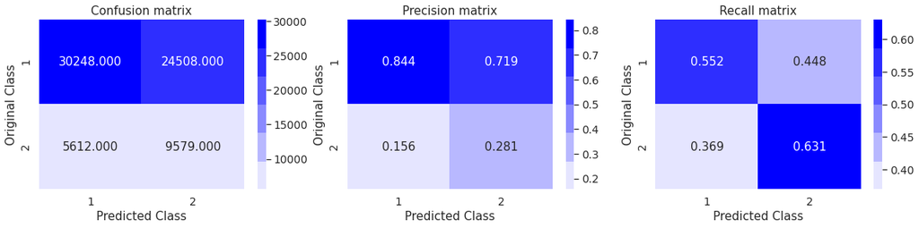

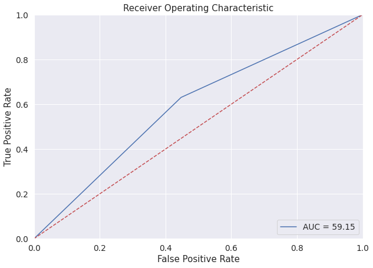

```python
train_model(lr)
```

## **OBSERVATION:**

- ### 1. The SKLearns Logistic Regression model has an accuracy of 57%, however as we can see from the Confusion Matrix, that the model is performing better as compared to the SGD Variant in classifying the Defaulters.
- ### 2. The AUC is roughly at 60 than compared to the Random Model's 50.

## **-> 12.4. DECISION TREE**

```
accuracy_score 67.5697313680358
precision_score 25.415053481199557
recall_score 25.495359094200516
f1_score 25.45514295103516
roc_auc_score 52.36890827089308
confusion_matrix
```

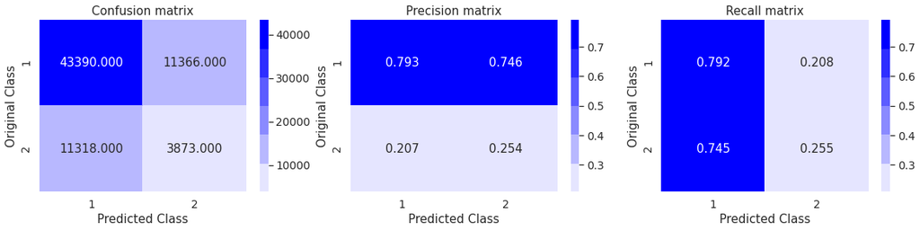

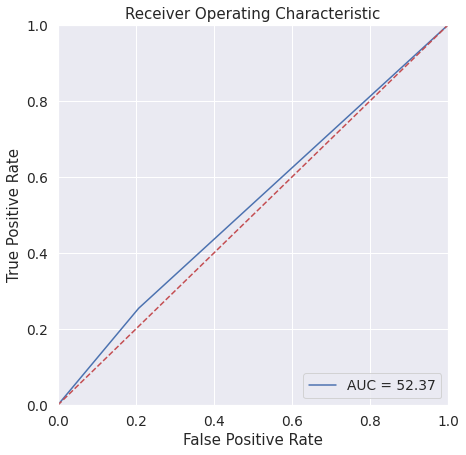

```python
train_model(dtc)
```

## **-> 12.5. KNN**

```python
a=15
a
```

```
15
```

```
accuracy_score 77.1069524068223
precision_score 33.85703063629222
recall_score 5.67441248107432
f1_score 9.719794779274961
roc_auc_score 51.29947521562664
confusion_matrix
```

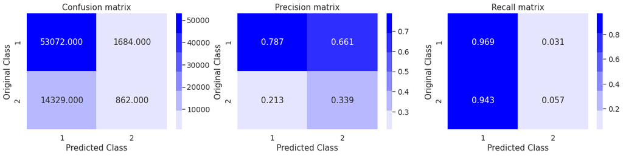

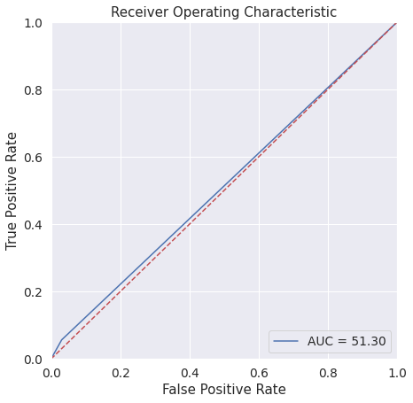

```python
train_model(knn)
```

## **OBSERVATION:**

- ### 1. KNN accuracy is very also high at 77 but the confusion matrix shows the poor performance in classifying defaulters than compared to the Logistic Regression which has lower accuracy.
- ### 2. AUC is same as Random Model.

## **-> 12.6. BAGGING: RANDOM FOREST CLASSIFIER**

```
accuracy_score 77.33283771998799
precision_score 33.04392236976506
recall_score 4.2591007833585675
f1_score 7.545629482768675
roc_auc_score 50.93242130993482
confusion_matrix
```

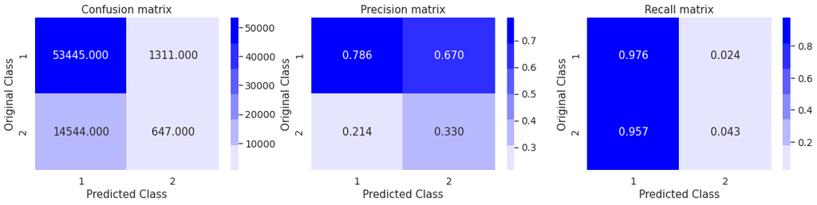

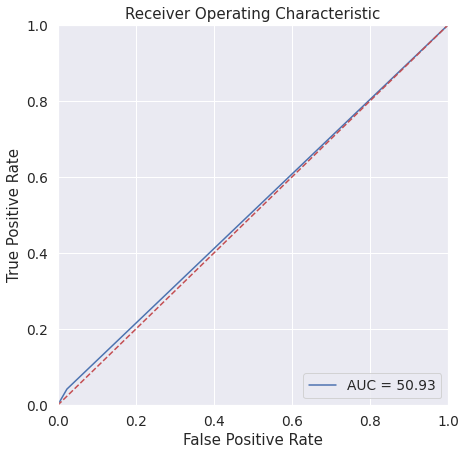

```python
train_model(rfc)
```